# Feature Engineering

Michał Stawikowski

01 - 04 - 2019

```r
knitr::opts_chunk$set(cache=TRUE)
```

# 1 Wstęp

W tym raporcie przedstawię wyniki inżynierii cech przeprowadzonej na zbiorze danych dotyczącym zakupów w sklepach `Walmart`. Celem `klasyfikacji multiklasowej` na tych danych jest określenie zmiennej `TripType`, czyli kategorii przeprowadzonych zakupów. Tak prezentuje się ramka danych i zmienne, którymi będziemy się kierować przy klasyfikacji.

```r
#Krótka EDA
introduce(data_raw)
```

| rows | columns | discrete_columns | continuous_columns | all_missing_columns | total_missing_values | complete_rows | total_observations | memory_usage |
| --- | --- | --- | --- | --- | --- | --- | --- | --- |
| 647054 | 7 | 2 | 5 | 0 | 8258 | 642925 | 4529378 | 20714712 |

```r
head(data_raw)
```

|  | TripType | VisitNumber | Weekday | Upc | ScanCount | DepartmentDescription | FinelineNumber |
| --- | --- | --- | --- | --- | --- | --- | --- |
| 1 | 999 | 5 | Friday | 68113152929 | -1 | FINANCIAL SERVICES | 1000 |
| 2 | 30 | 7 | Friday | 60538815980 | 1 | SHOES | 8931 |
| 3 | 30 | 7 | Friday | 7410811099 | 1 | PERSONAL CARE | 4504 |
| 4 | 26 | 8 | Friday | 2238403510 | 2 | PAINT AND ACCESSORIES | 3565 |
| 5 | 26 | 8 | Friday | 2006613744 | 2 | PAINT AND ACCESSORIES | 1017 |
| 6 | 26 | 8 | Friday | 2006618783 | 2 | PAINT AND ACCESSORIES | 1017 |

Postaram się pokazać jak dużą poprawę w skuteczności klasyfikacji może przynieść prosta obróbka danych. Na początku zaprezentuję zmiany, które donałem w wyjsciowej ramce danych, a następnie porównamy skuteczności modelu klasyfikującego przed i po dodaniu nowych cech. Surowa ramka danych nie składa się z unikatowych wizyt w sklepie, odbije się to prawdopodbnie na skuteczności trenowanego na niej modelu.

# 2 Feature engineering

```r
data <- na.omit(data_raw)

dataD <- cbind(data, dummy(data$DepartmentDescription, sep = "_"))


dataD <- dplyr::select(dataD, -c("TripType", "Weekday", "Upc", "ScanCount","FinelineNumber","DepartmentDescription"))

dataDFixed <- dataD %>% group_by(VisitNumber) %>% summarise_all(list(sum))

colnames(dataDFixed) <- make.names(names(dataDFixed),unique = F)
```

```r
head(dataDFixed)
```

| VisitNumber | data_1.HR.PHOTO | data_ACCESSORIES | data_AUTOMOTIVE | data_BAKERY | data_BATH.AND.SHOWER | data_BEAUTY | data_BEDDING | data_BOOKS.AND.MAGAZINES | data_BOYS.WEAR | data_BRAS...SHAPEWEAR | data_CAMERAS.AND.SUPPLIES | data_CANDY..TOBACCO..COOKIES | data_CELEBRATION | data_COMM.BREAD | data_CONCEPT.STORES | data_COOK.AND.DINE | data_DAIRY | data_DSD.GROCERY | data_ELECTRONICS | data_FABRICS.AND.CRAFTS | data_FINANCIAL.SERVICES | data_FROZEN.FOODS | data_FURNITURE | data_GIRLS.WEAR..4.6X..AND.7.14 | data_GROCERY.DRY.GOODS | data_HARDWARE | data_HEALTH.AND.BEAUTY.AIDS | data_HOME.DECOR | data_HOME.MANAGEMENT | … |
| --- | --- | --- | --- | --- | --- | --- | --- | --- | --- | --- | --- | --- | --- | --- | --- | --- | --- | --- | --- | --- | --- | --- | --- | --- | --- | --- | --- | --- | --- | --- |
| 5 | 0 | 0 | 0 | 0 | 0 | 0 | 0 | 0 | 0 | 0 | 0 | 0 | 0 | 0 | 0 | 0 | 0 | 0 | 0 | 0 | 1 | 0 | 0 | 0 | 0 | 0 | 0 | 0 | 0 | … |
| 7 | 0 | 0 | 0 | 0 | 0 | 0 | 0 | 0 | 0 | 0 | 0 | 0 | 0 | 0 | 0 | 0 | 0 | 0 | 0 | 0 | 0 | 0 | 0 | 0 | 0 | 0 | 0 | 0 | 0 | … |
| 8 | 0 | 0 | 0 | 0 | 0 | 0 | 0 | 0 | 0 | 0 | 0 | 0 | 0 | 0 | 0 | 0 | 1 | 1 | 0 | 0 | 0 | 0 | 0 | 0 | 0 | 0 | 0 | 0 | 0 | … |
| 9 | 0 | 0 | 0 | 0 | 0 | 0 | 0 | 0 | 0 | 0 | 0 | 0 | 0 | 0 | 0 | 0 | 0 | 0 | 0 | 0 | 0 | 0 | 0 | 0 | 0 | 0 | 0 | 0 | 0 | … |
| 10 | 0 | 0 | 0 | 0 | 0 | 0 | 0 | 0 | 0 | 0 | 0 | 1 | 0 | 0 | 0 | 0 | 0 | 2 | 0 | 0 | 0 | 0 | 0 | 0 | 0 | 0 | 0 | 0 | 0 | … |
| 11 | 0 | 0 | 0 | 0 | 0 | 0 | 0 | 0 | 0 | 0 | 0 | 0 | 0 | 0 | 0 | 0 | 0 | 1 | 0 | 0 | 0 | 0 | 0 | 0 | 1 | 0 | 0 | 0 | 0 | … |

Na początku za pomocą `dummy variables` zakodowaliśmy zmienną `DepartmentDescription`, w celu późniejszego grupowanie danych.

```r
#Grupowanie i sumowanie Department Descprition po podobieństwie

dataSum <-
dataDFixed %>%
  rowwise() %>%
  mutate(Food=sum(data_CANDY..TOBACCO..COOKIES, data_FROZEN.FOODS,data_DAIRY,data_GROCERY.DRY.GOODS,data_MEAT...FRESH...FROZEN,
                  data_SEAFOOD,data_BAKERY,data_COMM.BREAD,data_COOK.AND.DINE,
                  na.rm = T))

dataSum <-
dataSum %>%
  rowwise() %>%
  mutate(Lens=sum(data_OPTICAL...LENSES, data_OPTICAL...FRAMES,
                  na.rm = T))


dataSum <-
dataSum %>%
  rowwise() %>%
  mutate(MensWear=sum(data_MENSWEAR,data_MENS.WEAR,
                  na.rm = T))

dataSum <-
dataSum %>%
  rowwise() %>%
  mutate(Clothing=sum(data_SHOES,data_LADIESWEAR,data_LADIES.SOCKS,data_JEWELRY.AND.SUNGLASSES,data_BRAS...SHAPEWEAR,
                  na.rm = T))

dataSum <-
dataSum %>%
  rowwise() %>%
  mutate(KidsClothing=sum(data_BOYS.WEAR,data_GIRLS.WEAR..4.6X..AND.7.14,data_INFANT.APPAREL,
                  na.rm = T))

dataSum <-
dataSum %>%
  rowwise() %>%
  mutate(Look=sum(data_PERSONAL.CARE,data_BEAUTY,
                  na.rm = T))

dataSum <- dplyr::select(dataSum, -c(data_CANDY..TOBACCO..COOKIES, data_FROZEN.FOODS,data_DAIRY,data_GROCERY.DRY.GOODS,data_MEAT...FRESH...FROZEN,
                  data_SEAFOOD,data_BAKERY,data_COMM.BREAD,data_COOK.AND.DINE,data_OPTICAL...LENSES,data_MENS.WEAR,data_SHOES,data_LADIESWEAR,data_LADIES.SOCKS,data_JEWELRY.AND.SUNGLASSES,data_BRAS...SHAPEWEAR,data_BOYS.WEAR,data_GIRLS.WEAR..4.6X..AND.7.14,data_INFANT.APPAREL, data_PERSONAL.CARE,data_BEAUTY))
```

Kolejnym krokiem było pogrupowanie zmiennej `DepartmentDescription`. Storzyłem bardziej ogólne kategorie, takie jak:

- `Food` - składająca się z różnych rodzajów jedzenia
- `Clothing` - zbierająca rózne rodzaje ubrania dla dorosłych
- `KidsClothing` - analogicznej kolumny do poprzedniej tym razem dla dzieci

A także kilka innych składających się z błednie rozdzielonych kolumn jak `MENSWEAR` i `MENS.WEAR` lub grupując mniej liczne kategorie.

```r
fixed <- data %>% group_by(VisitNumber) %>% summarise(
            DistinctDepart = n_distinct(DepartmentDescription),
            DistinctProd = n_distinct(FinelineNumber),
            SumProd = sum(ScanCount),
            Spread = sd(ScanCount),
            AnyRet = any(ScanCount < 0),
            PurchasedProd = sum(ScanCount >= 0),
            ReturnedProd = sum(ScanCount < 0),
            TripType = first(TripType),
            WeekDay = first(Weekday))

# Łączymy dwie ramki

final <- left_join(fixed,dataSum,by="VisitNumber")
final <- dplyr::select(final, -c("VisitNumber"))
final$TripType <- factor(final$TripType)






colnames(final) <- make.names(names(final),unique = F)
```

```r
head(fixed)
```

| VisitNumber | DistinctDepart | DistinctProd | SumProd | Spread | AnyRet | PurchasedProd | ReturnedProd | TripType | WeekDay |
| --- | --- | --- | --- | --- | --- | --- | --- | --- | --- |
| 5 | 1 | 1 | -1 | NaN | TRUE | 0 | 1 | 999 | Friday |
| 7 | 2 | 2 | 2 | 0.0000000 | FALSE | 2 | 0 | 30 | Friday |
| 8 | 6 | 16 | 27 | 0.9223065 | TRUE | 20 | 2 | 26 | Friday |
| 9 | 2 | 3 | 3 | 0.0000000 | FALSE | 3 | 0 | 8 | Friday |
| 10 | 2 | 3 | 3 | 0.0000000 | FALSE | 3 | 0 | 8 | Friday |
| 11 | 3 | 4 | 4 | 0.0000000 | FALSE | 4 | 0 | 35 | Friday |

Następnie obie utworzone ramki łączymy ze sobą.

# 3 Dodatkowe modyfikacje

Niestety część modyfikacji, które chciałem wprowadzić okazały się trudne do osiągnięcia ze względu na ograniczoną moc obliczeniową. Przydatne mogło się okazać rozszerzenie zmiennych `Upc` oraz `FinelineNumber` tak jak zrobiliśmy to ze zmienną `DepartmentDescription`. Mogło okazać się to pomocne dla takiego algorytmu jak `xgboost`, który nie lubi skompresowanych danych, a lepiej mógłby sobie poradzić na dużej ilości zmiennych.

# 4 Ocena wprowadzonych zmian

Surową i obrobioną ramkę danych przetestujemy dokonując klasyfikacji za pomocą algorytmu `RandomForest`. Wyniki porównamy używając funkcji do walidacji wyników podanej wraz z pracą domową. Surowa ramka miała zbyt wiele poziomów w kolumnie `DepartmentDescription` dla tego klasyfikatora, więc została ograniczona do 50 najważniejszych.

## 4.1 Surowe dane

```r
final1<- na.omit(data_raw)
final1$DepartmentDescription <- fct_lump(final1$DepartmentDescription, 50)
train_setR <- final1[1:75750,]
test_setR <- final1[75750:100000,]


library(randomForest)
rfR <- randomForest(TripType~., data=train_setR)
scoresR <- predict(rfR, test_setR, type = "prob")

myScoresR <- sapply(1:nrow(test_setR), function(i){
  scoresR[i, test_setR$TripType[i]]
})

raw <- mean(-log(pmax(myScoresR,0.05)))
```

```r
raw
```

```
## [1] 1.971441
```

## 4.2 Obronione dane

```r
final<- na.omit(final)
train_set <- final[1:60000,]
test_set <- final[60000:75750,]





library(randomForest)
rf <- randomForest(TripType~., data=train_set)
scores <- predict(rf, test_set, type = "prob")

myScores <- sapply(1:nrow(test_set), function(i){
  scores[i, test_set$TripType[i]]
})

trans <- mean(-log(pmax(myScores,0.05)))
```

```r
trans
```

```
## [1] 1.078405
```

# 5 Wnioski

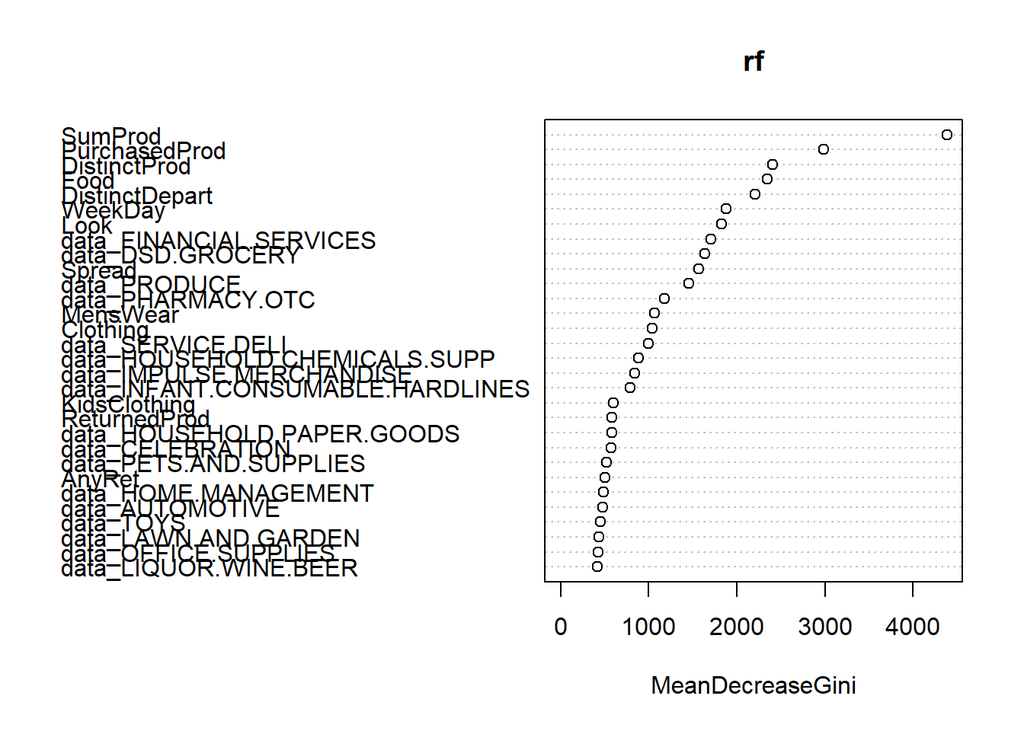

```r
library(randomForest)
varImpPlot(rf)
```